[California](https://www.latimes.com/california)

# Autism awareness really is growing, but harmful misconceptions still remain

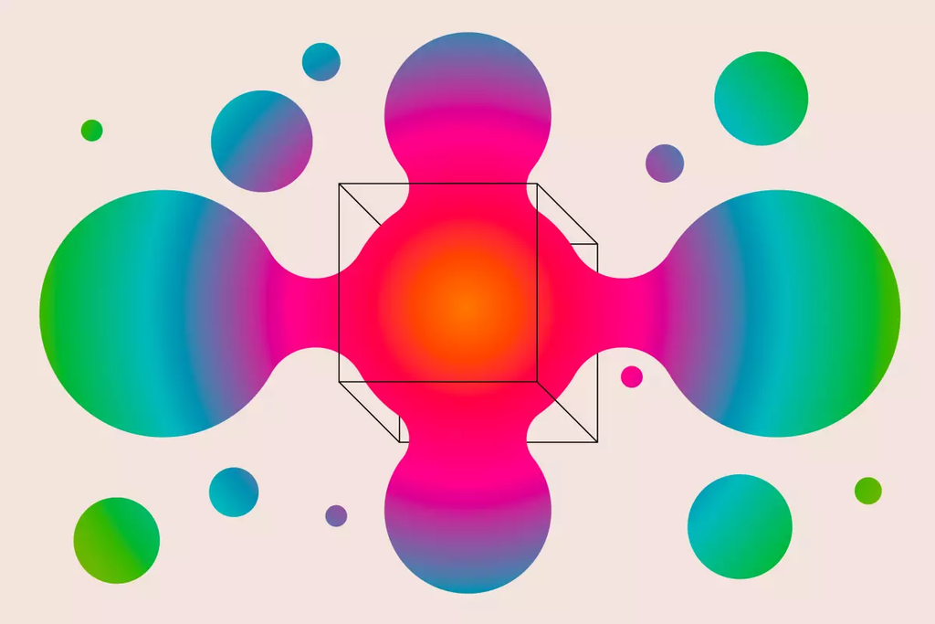

(Patrick Hruby / Los Angeles Times)

By [Laura Newberry](https://www.latimes.com/people/laura-newberry)Staff Writer

April 18, 2023 11:21 AM PT

*This story was originally published in Group Therapy, a weekly newsletter answering questions sent by readers about what’s been weighing on their hearts and minds.* [*Sign up here*](https://www.latimes.com/newsletters/sign-up-for-our-group-therapy-newsletter) *to get it in your inbox.*

Instagram and TikTok have been flooded with content made for and by neurodivergent people in recent years. In turn, many people have come across these videos and had life-changing realizations that they might be autistic or have attention-deficit hyperactivity disorder themselves — especially women, nonbinary folks and people of color, who are much more likely to go undiagnosed. Autism and ADHD were among the [most Googled mental health terms](https://bigthink.com/neuropsych/mental-health-google-searches-2021/) in 2021, eclipsed only by searches about anxiety and depression.

Given this (much-needed) growing awareness, it’s unsurprising that we’ve gotten a number of great questions about ADHD and autism from Group Therapy readers. But before getting to those, I wanted to lay some groundwork. There’s so much I myself still don’t know about neurodivergence, and I figured that a lot of our readers might be in the same boat.

So for the next three weeks, I’ll be writing a three-part series that explores the legacy of autism and the many misconceptions that still remain; the overlap between autism and ADHD; and the growing movement to self-diagnose neurodivergence. As always, you’re welcome to share your thoughts, questions and points you think we’ve missed.

Before we dive in, a quick note on the evolving concept of [neurodiversity](https://static1.squarespace.com/static/5d19af590969480001263f3c/t/6205a957a9e24f2db4d2786c/1644538200084/NeurodiversityTermstoKnow.pdf) and the language and terms you’ll see in our series.

“Neurodiversity” was coined in 1998 by Australian sociologist Judy Singer, who describes herself as being “likely somewhere on the autistic spectrum.” Though the idea originated in the autism community, all that falls under the [umbrella of neurodivergence](https://livedexperienceeducator.com/s/NeurodivergentUmbrella) — which describes people who have a mind that functions differently from what society considers typical — has expanded to include ADHD, dyslexia and many other conditions.

Additionally, like any other diverse community, some people in the autism community prefer to be called autistic or use the word as a noun, which you’ll see below. Others prefer what’s called “people first” language, in which someone is described as a person with autism. And some people do not like the term “neurodiverse,” and some do not consider autism a disability. When in doubt, it’s generally helpful to politely ask a friend or loved one what their preferences are, rather than assuming. You can read more about language by visiting the [National Center on Disability and Journalism style guide.](https://ncdj.org/style-guide/)

All right, let’s dive into Part 1 of our series.

## What is autism?

Autism is a neurological and developmental condition that affects how people interact with others, communicate, learn and behave. Most researchers now believe that autism is not one single entity but a cluster of underlying conditions that “produce a distinctive constellation of behavior and needs that manifest in different ways at various stages of an individual’s development,” writes journalist Steve Silberman in his great book, [“NeuroTribes: The Legacy of Autism and the Future of Neurodiversity.”](https://bookshop.org/p/books/neurotribes-the-legacy-of-autism-and-the-future-of-neurodiversity-steve-silberman/577423) Scientists have [identified more than 200 genes](https://www.statnews.com/2022/08/18/genetic-research-provides-new-clarity-about-whys-of-autism/) involved in autism and similar neurodevelopmental conditions.

There are many, many different ways that people experience autism. “Autistic people are as different and varied as the human experience itself,” said Eric Garcia, a senior Washington correspondent for the Independent and author of the book [“We’re Not Broken: Changing the Autism Conversation.”](https://bookshop.org/p/books/we-re-not-broken-changing-the-autism-conversation-eric-garcia/16104649?gclid=CjwKCAjw586hBhBrEiwAQYEnHb01vT1mT13c3IqgGXYDvfZ_nNzAusvkkPYjfmleUpnVHP3tYTkYihoCI9wQAvD_BwE)

A more nuanced, expansive view of autism has been a long time coming. At the same time, autism [wasn’t formally studied](https://www.ncbi.nlm.nih.gov/pmc/articles/PMC4725185/#B21) by medical establishment until the 1940s, making it a relatively new field of research, one that has shape-shifted immensely over the past eight decades.

Before 1980, when autism first appeared in the “Diagnostic and Statistical Manual of Mental Disorders” (DSM) *—* which is more or less the Bible of psychiatry — the disability was described as a form of childhood schizophrenia, and it was thought to be caused by cold and unemotional parenting (a theory that wasn’t disproven until the ‘60s and ‘70s). Parents in this era were routinely told that they had no choice but to institutionalize their autistic children.

The [addition of Asperger’s syndrome](https://www.ncbi.nlm.nih.gov/pmc/articles/PMC4725185/#B21) to the DSM in 1994 broadened the diagnostic boundaries of autism, and introduced to the public the concept of autism as a *spectrum* instead of a uniform condition. But this diagnosis also brought with it the labels of “high-functioning” and “low-functioning” (we’ll return to that in a minute), and activists and scholars called into question whether there was actually any meaningful difference between Asperger’s and the rest of the spectrum. Asperger’s was removed from the DSM in 2013 and folded into the autism spectrum of disorders. Though some people still call themselves “Aspies,” others dropped the self-descriptor when it was revealed that the [man whom the condition was named after](https://time.com/5255779/asperger-syndrome-nazi-germany-history/) was a supporter of the Nazi regime during World War II.

“The common thread between most of these changes is that autistic people didn’t have a say in them,” Garcia told me. “If you don’t have the input of autistic people, then the systems are going to inherently fail them.”

## Common experiences of autistic people

These are the characteristics that many autistic people have in common, according to the [Autistic Self Advocacy Network](https://autisticadvocacy.org/about-asan/about-autism/), a national grassroots disability rights organization run by and for the autistic community:

- **Thinking differently:** “We may have very strong interests in things other people don’t understand or seem to care about. We might be great problem-solvers, or pay close attention to detail. It might take us longer to think about things. We might have trouble with executive functioning, like figuring out how to start and finish a task, moving on to a new task, or making decisions.”
- **Routines are important for many autistic people.** “It can be hard for us to deal with surprises or unexpected changes. When we get overwhelmed, we might not be able to process our thoughts, feelings and surroundings, which can make us lose control of our body.”
- **Processing senses differently:** “We might be extra sensitive to things like bright lights or loud sounds. We might have trouble understanding what we hear or what our senses tell us. We might not notice if we are in pain or hungry. We might do the same movement over and over again. This is called ‘stimming,’ and it helps us regulate our senses. For example, we might rock back and forth, play with our hands, or hum.”
- **Moving differently:** “We might have trouble with fine motor skills or coordination. It can feel like our minds and bodies are disconnected. It can be hard for us to start or stop moving. Speech can be extra hard because it requires a lot of coordination. We might not be able to control how loud our voices are, or we might not be able to speak at all — even though we can understand what other people say.”
- **Communicating differently:** “We might talk using echolalia (repeating things we have heard before), or by scripting out what we want to say … we may communicate by typing on a computer, spelling on a letter board, or pointing to pictures on an iPad. Some people may also communicate with behavior or the way we act.”
- **Socializing differently:** “Some of us might not understand or follow social rules that non-autistic people made up. We might be more direct than other people. Eye contact might make us uncomfortable. We might have a hard time controlling our body language or facial expressions, which can confuse non-autistic people or make it hard to socialize.”
- **Processing feelings:** “Some of us might not be able to guess how people feel. This doesn’t mean we don’t care how people feel! We just need people to tell us how they feel so we don’t have to guess. Some autistic people are extra sensitive to other people’s feelings.”

There are many people who recognize some of these traits in themselves but may not qualify for a diagnosis according to the Diagnostic and Statistical Manual of Mental Disorders, or the DSM.

Social psychologist Devon Price points out that there is no clear line that we as a society can draw in the sand where a person is unquestionably “autistic enough” to count as “disabled in the eyes of all clinicians.”

“There’s an immense gray area, and we often find that the relatives of autistic people exhibit numerous autistic traits,” said Price, an autism rights advocate and author of “Unmasking Autism: Discovering the New Faces of Neurodiversity.” “So do people with ‘sister conditions’ such as ADHD, Tourette’s, social anxiety disorder or sensory processing disorder. As a community, neurodiverse people are a wide, diverse tent — and it’s better that we all recognize this, and communicate across identities about our shared concerns and the struggles we have in common.”

## Unpacking what you think you know about autism

Autism advocate Stephen Shore has famously said: “If you’ve met one person with autism, you’ve met one person with autism.”

Shore was rightly emphasizing the vast diversity within the autism spectrum. Unfortunately, many people understand autism as a collection of stereotypes that haven’t caught up with a more expansive understanding of what it means to be autistic.

Garcia noted that a long-standing stereotypical portrait of an autistic person is that of a middle- or upper-class white cisgender boy or man. This image has been fueled by the fact that, because [of racial inequities](https://www.ncbi.nlm.nih.gov/pmc/articles/PMC8500365/) in diagnosis and treatment, white children and those of higher socioeconomic status are more likely to be diagnosed than Black, Latinx and Asian children, as well as children from low-income families.

Women and nonbinary people have also been [historically underdiagnosed](https://www.psychologytoday.com/us/blog/understanding-the-diversity-in-neurodiversity/202202/autism-is-underdiagnosed-in-girls-and), in large part because of [“masking,”](https://www.npr.org/2022/04/14/1092869514/unmasking-autism-more-inclusive-world) or the act of hiding autistic traits as a survival mechanism. Because of the social expectations placed on them, masking is more common among people socialized as girls.

Autism has also been perceived as existing at two poles: You can’t speak or work, or you’re an eccentric Silicon Valley “coder” type — “but no people in between,” Garcia said.

This binary speaks to the pernicious labels of “high-functioning” and “low-functioning” autism, which define autistic people by how neurotypical people perceive them, rather than how autistic people see themselves or what they need, Garcia and Price both stressed.

“Autistics may appear to function ‘highly’ because we can imitate neuro-conforming speech patterns well, or because if we have to, we can hold down a job — but if we only measure a person’s disability based on this limited viewpoint, we can’t appreciate how much pain and struggle goes into propping that illusion of functioning up. Autistic people who ‘mask’ as neuro-conforming in order to get by at school or at work often have no energy left afterwards for things like meal planning, cooking, cleaning their house, or even socializing or pursuing beloved hobbies,” Price said.

And those labels are just too simplistic to capture the broad spectrum of autistic gifts and challenges. Garcia said he knows plenty of people who can speak and are brilliant on social media, but they’ve also really struggled to get through high school and college. And he knows others who can’t speak but have college degrees and maintain successful careers. Who among these people should be described as “high-functioning”?

“I can complete a PhD dissertation and write books with ease, for example, but even after 35 years of social practice, I cannot approach a person cold and start up a conversation with them. I just can’t. I only learned how to cook this year,” Price told me. “I can’t follow complex verbal instructions. If I have too many in-person meetings at my job, I can’t sleep or eat and I storm around my house all night hitting myself on the legs and arms and in the head because I’m so overwhelmed. I am no different from my ‘low-functioning’ autistic peers, I just can hide certain traits a little bit better, for a short period of time, and at immense personal cost.”

Garcia and Devon argue that regardless of how autism presents, it *is* a disability, one that our culture has by and large done a poor job of accommodating.

Prevailing models of “support” for autism have instead tried to cure it; a good example of this is applied behavior analysis, which involves as much as 40 hours a week of therapy and teaches social skills through unrelenting drills — which critics [say forces people on the spectrum](https://www.theatlantic.com/health/archive/2016/08/aba-autism-controversy/495272/) to hide who they are in the name of “maladaptive behavior reduction.” This is the most commonly used form of therapy for children with autism.

Instead of forcing autistic people to change, autism rights activists are pushing for our culture to change. “Designing appropriate forms of support and accommodation is not beyond our capabilities as a society, as the history of the disability rights movement proves,” Silberman wrote. “But first we have to learn and think more intelligently about people who think differently.”

Supportive innovations that have been suggested by autistic self-advocates and parents include [designated quiet areas in schools,](https://professionallearningboard.com/autistic-students-love-these-sensory-spaces-in-the-classroom/#:~:text=What%20are%20Sensory%20Spaces%3F,students%20with%20specific%20sensory%20input.) where an overwhelmed student could avoid a meltdown, and minimizing sensory input (like buzzing fluorescent lights), according to Silberman. Individualized education program, or IEPs, could focus on leveraging a child’s strengths and interests instead of addressing only their deficits.

I asked Price how a more nuanced understanding of autism might help shape the way neurotypical people respond to traits or behaviors that are outside of cultural norms.

“If neuro-conforming people could just broaden their sense of what ‘socially acceptable’ behavior is, a lot of people would get more free and more comfortable really quickly — and not just autistics,” Price said. “There’s no reason we need to act as though a person avoiding eye contact means they are a liar or being suspicious. Getting rid of that social expectation would help autistics move more freely through the world. It would also improve life for immigrants from cultures where eye contact is considered rude.

“Similarly, autistics could stand to gain a whole lot from us normalizing things like hand-flapping in public, wearing loose, comfortable clothes, giving honest, literal answers to questions instead of indirect and vague ones, and wearing sensory-friendly gear in public,” Price said. “These accommodations cost absolutely nothing, but if we simply accepted them, and accepted that some people move differently, feel differently and speak differently from others, every single one of us would experience greater social ease — not just disabled people, but anyone who has ever made the social mistake of being a little odd, which is just about all of us.”

Until next week,

Laura

*If what you learned today from these experts spoke to you or you’d like to tell us about your own experiences, please email us and let us know if it is OK to share your thoughts with the larger Group Therapy community. The email* *GroupTherapy@latimes.com* *gets right to our team. As always, find us on Instagram at* [*@latimesforyourmind*](https://www.instagram.com/latimesforyourmind/?hl=en)*, where we’ll continue this conversation.*

*See* [*previous editions here*](https://www.latimes.com/newsletters/sign-up-for-our-group-therapy-newsletter)*.* *To view this newsletter in your browser**,* [*click here*](https://www.latimes.com/california/newsletter/2023-04-18/autism-awareness-really-is-growing-but-harmful-misconceptions-still-remain-group-therapy)*.*

## More perspectives on today’s topic & other resources

“**Autism is a spectrum” doesn’t mean what you think,** writes author C.L. Lynch. I first read [this piece](https://neuroclastic.com/its-a-spectrum-doesnt-mean-what-you-think/) during my training at the Los Angeles LGBT Center, where I’m a therapy intern, and it shifted my understanding of autism more than anything I’ve ever read. “Autism isn’t one condition,” Lynch writes. “It is a collection of related neurological conditions that are so intertwined and so impossible to pick apart that professionals have stopped trying.”

**When Price first started writing** [**about** **autism**](https://www.latimes.com/local/autism/la-me-discovering-autism-20160211-storygallery.html) **online in 2018**, he received countless 5,000-plus-word emails from adults asking him, “Am I Autistic?” But for adults, there are no diagnostic criteria for autism. In Price’s book “[Unmasking Autism](https://bookshop.org/a/7748/9780593235232),” he presents a clear definition of autism and the anatomy of masking. He [talked with the L.A. Times](https://www.latimes.com/entertainment-arts/books/story/2022-04-07/the-transgender-proud-autistic-psychologist-who-believes-we-have-autism-all-wrong) about the book last year.

**Autistic people didn’t always have a platform or readily available community.** Now, they’re [finding acceptance, confidence and connection on TikTok.](https://www.buzzfeednews.com/article/katiecamero/autistic-people-connecting-on-tiktok) “I went from thinking I was alone with my struggles and experiences to seeing many who understand me,” one person told BuzzFeed. “It was an overwhelming experience at first, but watching [autistic people] and communicating with them became the best thing to come from TikTok. I’ve learned more about myself through them.”

## Other interesting stuff

**Our sense of smell is deeply linked to our emotions.** But what if those smells are also linked to traumatic memories? Researchers are finding success using a combination of artificial scents and virtual reality to treat people with severe cases of trauma, according to the Wall Street Journal’s [“The Future of Everything” podcast.](https://www.wsj.com/podcasts/wsj-the-future-of-everything/how-smell-is-helping-treat-the-toughest-cases-of-trauma/08c7b400-0f9f-45c5-af34-e69a51a4c35f)

**“The death penalty is a divisive issue that has well-meaning people arguing for similar goals but by different means,”** writes Dr. Joseph Thornton [for the Florida Times-Union.](https://www.jacksonville.com/story/opinion/columns/guest/2023/03/18/execution-of-mentally-ill-is-only-retribution-doesnt-make-us-safer/70008129007/) “As a former psychiatrist treating Florida death row prisoners, I argue we should not be executing anyone,” he goes on — especially people struggling with serious mental health challenges.

[Laura Newberry](https://www.latimes.com/people/laura-newberry)

Laura Newberry is a former reporter with the lifestyle section at the Los Angeles Times. She wrote Group Therapy, a weekly newsletter that answers readers’ questions about mental health. She previously worked on The Times’ education team and was a staff reporter at both the Reading Eagle in Eastern Pennsylvania and MassLive in Western Massachusetts. She graduated from UC Berkeley’s Graduate School of Journalism and also has a master’s degree in social work from the University of Central Florida.

[figure not shown]

[figure not shown]

[figure not shown]

[figure not shown]

[figure not shown]